# The Beta Distribution

STA421

## History of the Beta distribution:

**1763:** Beta distribution as density of the probabilities of Bernoulli trials (did not go into details of the properties)  
(Work of Bayes published after his death by Richard Price)

**1895:** Systematic Discussion by Karl Pearson \(\rightarrow\) Prior WWII Beta distribution known as Pearson Type 1 distribution (a generalization of the Beta distribution)

[figure not shown]

Thomas Bayes: 1701-1761

## Properties of the Beta distribution:

Continuous density function defined on the interval \([0,1]\) \(f(x)=\frac{1}{B(\alpha,\beta)}x^{\alpha-1}(1-x)^{\beta-1}\)  
with the two shape parameters \(\alpha,\beta>0\)

Normalization assured by Beta-function: \(B(\alpha,\beta)=\dfrac{\Gamma(\alpha)\Gamma(\beta)}{\Gamma(\alpha+\beta)}=\dfrac{(\alpha-1)!(\beta-1)!}{(\alpha+\beta-1)!}\)

Expectation value: \(E(X)=\dfrac{\alpha}{\alpha+\beta}\)

Variance: \(Var(X)=\dfrac{\alpha\beta}{(\alpha+\beta+1)(\alpha+\beta)^2}\)

## Idea of the parameters:

In probability context and without the normalization constant:  
\[ f(p)\propto p^{\alpha-1}(1-p)^{\beta-1} \]  
Remember Binomial: \(f(k;p,n)=\binom{n}{k}p^{k}(1-p)^{n-k}\) with

- \(k=\#Successes\)
- \(n=\#trials\)

Thus can be seen as:

- \(\alpha-1=\#Successes\)
- \(\beta-1=\#Failures\)

## Properties of the Beta distribution 1:

- The higher \(\beta\) (\(\#Failures\)) the more shifted towards lower probabilities
- The higher \(\alpha\) (\(\#Successes\)) the more shifted towards higher probabilities

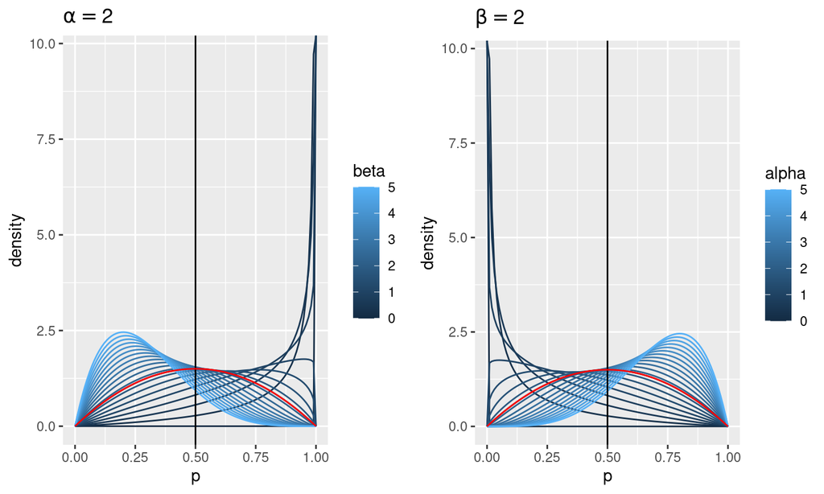

## Properties of the Beta distribution 2:

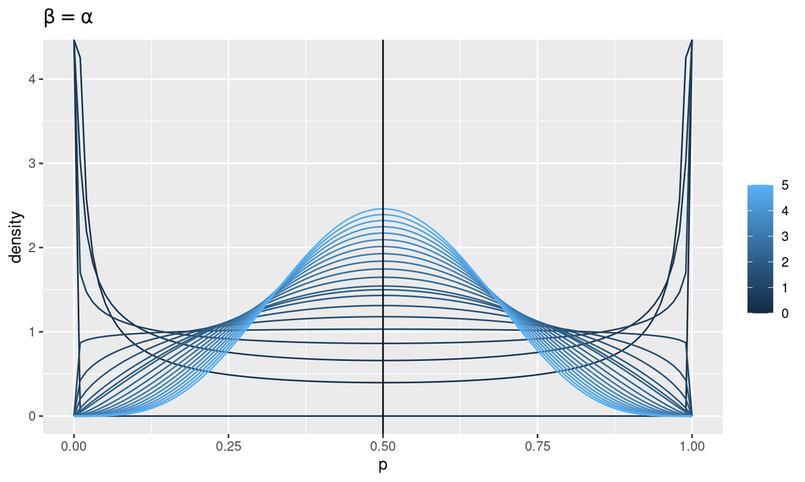

## Properties of the Beta distribution 3:

Expectation value: \(E(X)=\dfrac{\alpha}{\alpha+\beta}=\dfrac{\lambda\alpha}{\lambda(\alpha+\beta)}=\dfrac{\lambda\alpha}{\lambda\alpha+\lambda\beta}\)

Variance: \(Var(X)=\dfrac{\lambda\alpha\lambda\beta}{(\lambda\alpha+\lambda\beta+1)(\lambda\alpha+\lambda\beta)^2}=\dfrac{\alpha\beta}{(\lambda\alpha+\lambda\beta+1)(\alpha+\beta)^2}\)

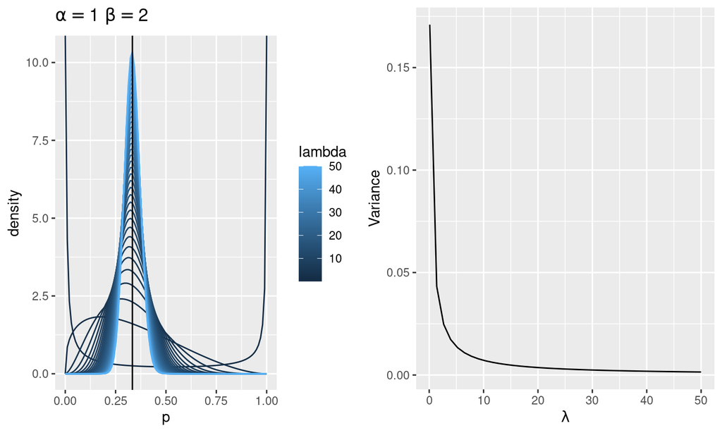

## Properties of the Beta distribution 4:

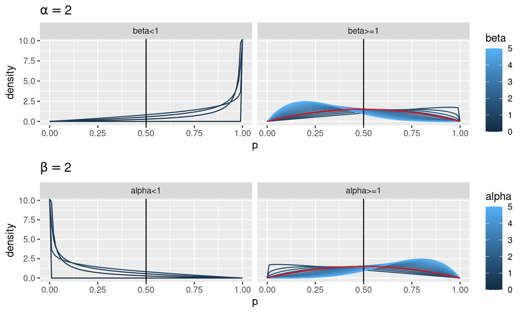

**Overall: Is a flexible continuous density function to model probabilities!**

## Reference:

- https://en.wikipedia.org/wiki/Beta_distribution#Mean_and_sample_size
- http://varianceexplained.org/statistics/beta_distribution_and_baseball/